# Neural Networks

# Neural Network with Boston Dataset

Here we are going to use the Boston datset in order to train a neural network to determine the median value of owner-occupied homes in $1000’s. A brief summary of the headers is listed below:

```
Concerns housing values in suburbs of Boston.

1. CRIM: per capita crime rate by town
2. ZN: proportion of residential land zoned for lots over 25,000 sq.ft.
3. INDUS: proportion of non-retail business acres per town
4. CHAS: Charles River dummy variable (= 1 if tract bounds river; 0 otherwise)
5. NOX: nitric oxides concentration (parts per 10 million)
6. RM: average number of rooms per dwelling
7. AGE: proportion of owner-occupied units built prior to 1940
8. DIS: weighted distances to five Boston employment centres
9. RAD: index of accessibility to radial highways
10. TAX: full-value property-tax rate per $10,000
11. PTRATIO: pupil-teacher ratio by town
12. B: 1000(Bk - 0.63)^2 where Bk is the proportion of blacks by town
13. LSTAT: % lower status of the population
14. MEDV: Median value of owner-occupied homes in $1000's
```

```r
# Clean Workspace
rm(list = ls())

library(MASS)

# For clean looking data
library(tibble)

# Check for Missing Data
any(is.na(Boston))
```

```
## [1] FALSE
```

```r
DT::datatable(as.tibble(Boston))
```

|  | crim | zn | indus | chas | nox | rm | age | dis | rad | tax | ptratio | black | lstat | medv |
| --- | --- | --- | --- | --- | --- | --- | --- | --- | --- | --- | --- | --- | --- | --- |
| 1 | 0.00632 | 18 | 2.31 | 0 | 0.538 | 6.575 | 65.2 | 4.09 | 1 | 296 | 15.3 | 396.9 | 4.98 | 24 |
| 2 | 0.02731 | 0 | 7.07 | 0 | 0.469 | 6.421 | 78.9 | 4.9671 | 2 | 242 | 17.8 | 396.9 | 9.14 | 21.6 |
| 3 | 0.02729 | 0 | 7.07 | 0 | 0.469 | 7.185 | 61.1 | 4.9671 | 2 | 242 | 17.8 | 392.83 | 4.03 | 34.7 |
| 4 | 0.03237 | 0 | 2.18 | 0 | 0.458 | 6.998 | 45.8 | 6.0622 | 3 | 222 | 18.7 | 394.63 | 2.94 | 33.4 |
| 5 | 0.06905 | 0 | 2.18 | 0 | 0.458 | 7.147 | 54.2 | 6.0622 | 3 | 222 | 18.7 | 396.9 | 5.33 | 36.2 |
| 6 | 0.02985 | 0 | 2.18 | 0 | 0.458 | 6.43 | 58.7 | 6.0622 | 3 | 222 | 18.7 | 394.12 | 5.21 | 28.7 |
| 7 | 0.08829 | 12.5 | 7.87 | 0 | 0.524 | 6.012 | 66.6 | 5.5605 | 5 | 311 | 15.2 | 395.6 | 12.43 | 22.9 |
| 8 | 0.14455 | 12.5 | 7.87 | 0 | 0.524 | 6.172 | 96.1 | 5.9505 | 5 | 311 | 15.2 | 396.9 | 19.15 | 27.1 |
| 9 | 0.21124 | 12.5 | 7.87 | 0 | 0.524 | 5.631 | 100 | 6.0821 | 5 | 311 | 15.2 | 386.63 | 29.93 | 16.5 |
| 10 | 0.17004 | 12.5 | 7.87 | 0 | 0.524 | 6.004 | 85.9 | 6.5921 | 5 | 311 | 15.2 | 386.71 | 17.1 | 18.9 |

[output cut: 496 more lines]

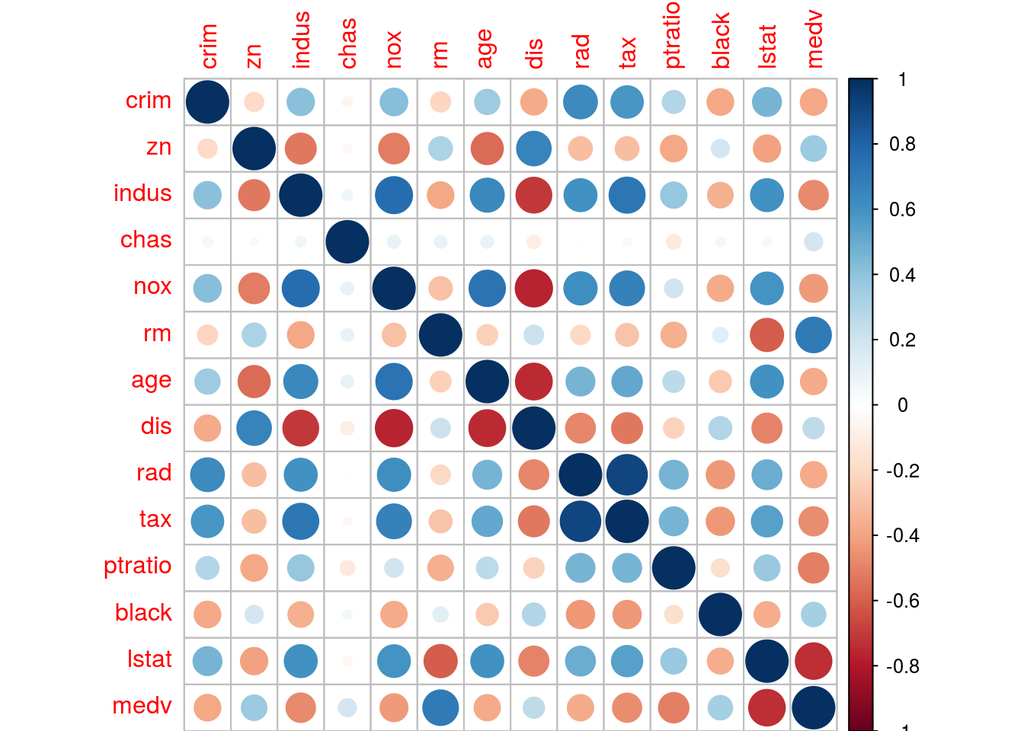

```r
# Rename Boston to data.
data = Boston

# I like corrplot and no markdown file is complete without a pretty plot.
library(corrplot)
mcor = round(cor(Boston), 2)
corrplot(mcor)
```

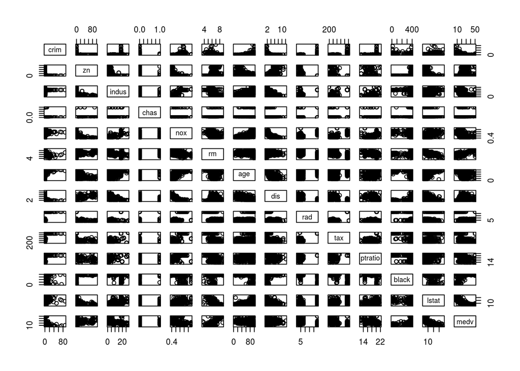

```r
plot(Boston)
```

## Normalizing the Data

```r
# Get max and min of each row to scale the data.
maxs = apply(data, 2, max)
mins = apply(data, 2, min)

scaled.data = scale(data,
                    center = mins,
                    scale = maxs-mins)

scaled = as.data.frame(scaled.data)

head(round(scaled, 5))
```

```
##      crim   zn   indus chas     nox      rm     age     dis     rad
## 1 0.00000 0.18 0.06782    0 0.31481 0.57751 0.64161 0.26920 0.00000
## 2 0.00024 0.00 0.24230    0 0.17284 0.54800 0.78270 0.34896 0.04348
## 3 0.00024 0.00 0.24230    0 0.17284 0.69439 0.59938 0.34896 0.04348
## 4 0.00029 0.00 0.06305    0 0.15021 0.65856 0.44181 0.44854 0.08696
## 5 0.00071 0.00 0.06305    0 0.15021 0.68710 0.52832 0.44854 0.08696
## 6 0.00026 0.00 0.06305    0 0.15021 0.54972 0.57467 0.44854 0.08696
##       tax ptratio   black   lstat    medv
## 1 0.20802 0.28723 1.00000 0.08968 0.42222
## 2 0.10496 0.55319 1.00000 0.20447 0.36889
## 3 0.10496 0.55319 0.98974 0.06347 0.66000
## 4 0.06679 0.64894 0.99428 0.03339 0.63111
## 5 0.06679 0.64894 1.00000 0.09934 0.69333
## 6 0.06679 0.64894 0.99299 0.09603 0.52667
```

## Split `data`

```r
library(caTools)
split = sample.split(scaled$medv, SplitRatio = 0.7)

train = subset(scaled, split == T)
test = subset(scaled, split == F)
```

## Being Lazy, Easy Function Creation

```r
n = names(train)
f = as.formula(paste("medv ~",
                     paste(n[!n %in% "medv"],
                           collapse = " + ")))
f
```

```
## medv ~ crim + zn + indus + chas + nox + rm + age + dis + rad +
##     tax + ptratio + black + lstat
```

## Creating the Neural Network

```r
library(neuralnet)
nn = neuralnet(f, data = train,
               hidden = c(5, 3),
               linear.output = TRUE)
```

## Plot of the Neural Network

This is likely to be an incredibly unlikely source of information. One of the issues with deep learning is that it is indeed… deep. The more perceptrons used, the less interpretable the model becomes.

```r
plot(nn)
```

[output not shown]

## Predicted Values

```r
predicted.nn.values = compute(nn, test[1:13])

# Inverting the scaling done before.
true.predictions = predicted.nn.values$net.result *
                    (max(data$medv) - min(data$medv)) + min(data$medv)

# Rescale the test data
test.r = (test$medv)*(max(data$medv) - min(data$medv)) + min(data$medv)

# Check MSE
MSE.nn = sum((test.r - true.predictions)^2)/nrow(test)

# Create data.frame to view accuracy solution.
error.df = data.frame(test.r, true.predictions)
head(error.df)
```

```
##    test.r true.predictions
## 4    33.4      29.44742515
## 5    36.2      30.68241146
## 19   20.2      19.38021680
## 21   13.6      13.86471678
## 23   15.2      15.30089227
## 24   14.5      14.34929431
```

## Plot of the Solution

```r
library(ggplot2)
library(ggthemes)
library(plotly)
gg = ggplot(error.df, aes(x=test.r, y = true.predictions)) +
     geom_point() +
     stat_smooth() +
     theme_economist() +
     xlab("Test Values") +
     ylab("Predictions: Unscaled Prediction of NN") +
     ggtitle("Results of Neural Net")

ggplotly(gg)
```

[interactive chart not shown]

# Neural Network with the Banknote Authentication Data Set

### Data Set Information:

Data were extracted from images that were taken from genuine and forged banknote-like specimens. For digitization, an industrial camera usually used for print inspection was used. The final images have 400x 400 pixels. Due to the object lens and distance to the investigated object gray-scale pictures with a resolution of about 660 dpi were gained. Wavelet Transform tool were used to extract features from images.

```
1. variance of Wavelet Transformed image (continuous)
2. skewness of Wavelet Transformed image (continuous)
3. curtosis of Wavelet Transformed image (continuous)
4. entropy of image (continuous)
5. class (integer)
```

Click here for information on wavelet transformation.

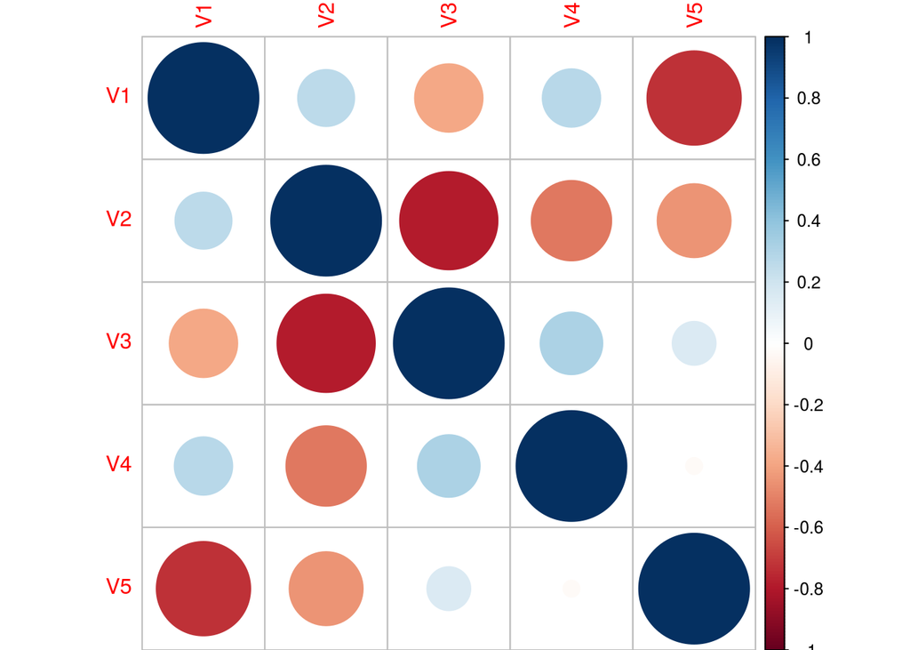

```r
library(data.table)
data = fread("https://archive.ics.uci.edu/ml/machine-learning-databases/00267/data_banknote_authentication.txt")

corrplot(round(cor(data), 3))
```

## Normalizing the Data

```r
# Get max and min of each row to scale the data.
maxs = apply(data, 2, max)
mins = apply(data, 2, min)

scaled.data = scale(data,
                    center = mins,
                    scale = maxs-mins)

scaled = as.data.frame(scaled.data)

head(round(scaled, 5))
```

```
##        V1      V2      V3      V4 V5
## 1 0.76900 0.83964 0.10678 0.73663  0
## 2 0.83566 0.82098 0.12180 0.64433  0
## 3 0.78663 0.41665 0.31061 0.78695  0
## 4 0.75711 0.87170 0.05492 0.45044  0
## 5 0.53158 0.34866 0.42466 0.68736  0
## 6 0.82286 0.87727 0.05710 0.48971  0
```

## Split `data`

```r
library(caTools)
split = sample.split(scaled$V5, SplitRatio = 0.7)

train = subset(scaled, split == T)
test = subset(scaled, split == F)
```

## Being Lazy, Easy Function Creation

```r
n = names(train)
f = as.formula(paste("V5 ~",
                     paste(n[!n %in% "V5"],
                           collapse = " + ")))
f
```

```
## V5 ~ V1 + V2 + V3 + V4
```

```r
library(neuralnet)
nn = neuralnet(f, data = train,
               hidden = c(5, 3),
               linear.output = FALSE)
```

## Plot of the Neural Network

```r
plot(nn)
```

[output not shown]

## Predicted Values

```r
predicted.nn.values = compute(nn, test[1:4])

# Inverting the scaling done before.
true.predictions = predicted.nn.values$net.result *
                    (max(data$V5) - min(data$V5)) + min(data$V5)

# Rescale the test data
test.r = (test$V5)*(max(data$V5) - min(data$V5)) + min(data$V5)

# Check MSE
MSE.nn = sum((test.r - true.predictions)^2)/nrow(test)

# Create data.frame to view accuracy solution.
error.df = data.frame(test.r, true.predictions)
```

Woah, perfect classifications.

```r
table(round(true.predictions), test.r)
```

```
##    test.r
##       0   1
##   0 229   0
##   1   0 183
```

# Bank Authentication Data Set with Random Forest

```r
library(randomForest)
data$V5 = as.factor(data$V5)
split = sample.split(data$V5, SplitRatio = 0.70)

train = subset(data, split == TRUE)
test = subset(data, split == FALSE)
```

## Random Forest Model

Good model!

```r
rf.model = randomForest(V5 ~., data=train)
rf.pred = predict(rf.model, test)
table(rf.pred, test$V5)
```

```
##
## rf.pred   0   1
##       0 229   0
##       1   0 183
```